# Synteny Block Calculation

Fabian Grandke

2016-10-17

# Introduction

Detection of homeologous translocations require to know which SNPs belong to corresponding homeologous regions. In this manual we describe two different methods how to match homeologous regions between subgenomes and create synteny blocks. First we use publicly available data from already mapped gene sequences. Secondly, we create synteny blocks from genome sequences (fasta format) of corresponding subgenomes using the *DECIPHER* package.

We require some packages to be installed:

```r
library(openxlsx)
library(dbscan)
library(gsrc)
```

# Synteny blocks from mapped gene sequences

[Bancroft et al. (2015)](http://www.sciencedirect.com/science/article/pii/S2352340915000062) mapped gene sequences to the A and C subgenome of allotetraploid Brassica napus to match homeologous regions. We download the supplementary files 6 and 7:

```r
tf1 <- tempfile()
url1 <- paste("http://www.sciencedirect.com/science/MiamiMultiMediaURL/",
              "1-s2.0-S2352340915000062/1-s2.0-S2352340915000062-mmc6.xlsx/",
              "311593/html/S2352340915000062/5528a88e468e01866744f28fc42139c6/",
              "mmc6.xlsx", sep = "")
utils::download.file(url = url1, destfile = tf1, method = "internal", mode = "wb")
synA <- openxlsx::read.xlsx(tf1)
url2 <- paste("http://www.sciencedirect.com/science/MiamiMultiMediaURL/",
              "1-s2.0-S2352340915000062/1-s2.0-S2352340915000062-mmc7.xlsx/",
              "311593/html/S2352340915000062/d616ded5ee9399d4fe29df72435780c9/",
              "mmc7.xlsx", sep = "")
utils::download.file(url = url2, destfile = tf1, method = "internal", mode = "wb")
synC <- openxlsx::read.xlsx(tf1)
unlink(tf1)
```

## Filter data

The data set consists of two tabled of genes that have been mapped to the A and C genomes. Some genes could only be mapped to one of them and we want to filter these out.

```r
synA <- synA[synA$unigene %in% synC$unigene, ]
synC <- synC[synC$unigene %in% synA$unigene, ]
```

Additionally, we filter data entries, which do not have a unigene identifier.

```r
synA <- synA[!is.na(synA$unigene),]
synC <- synC[!is.na(synC$unigene),]
```

We drop some unused columns.

```r
synA <- synA[, c(2,5,6,7)]
synC <- synC[, c(2,5,6,7)]
```

## Merge data sets

Now, we merge the two tables with genes mapped to the A and C subgenome.

```r
syn_uni <- merge(synA, synC, by = "unigene")
syn_uni <- syn_uni[order(syn_uni$A.Chr, syn_uni$A.start),]
```

We create four columns from the existing data and add them to the dataset.

```r
syn_uni$Alev <- as.factor(syn_uni$A.Chr)
syn_uni$Clev <- as.factor(syn_uni$C.Chr)
syn_uni$AGlo <- syn_uni$A.start
syn_uni$CGlo <- syn_uni$C.start
```

## Calculate overall genomic positions

We use the positions of the genes to calculate the chromosome lengths. They are added to the positions to calculate global positions. For instance, if chromosome A1 is 3,000,000 bp long, position 150,000 on chromosome A2 becomes 3,150,000 globally. Global positions are required for plotting all SNPs together on a row.

```r
amaxs <- sapply(levels(syn_uni$Alev), function(x) max(syn_uni$A.start[syn_uni$A.Chr==x]))
for(i in 2:length(levels(syn_uni$Alev))){
  syn_uni$AGlo[syn_uni$A.Chr == levels(syn_uni$Alev)[i]] <- syn_uni$AGlo[syn_uni$A.Chr == levels(syn_uni$Alev)[i]] + sum(amaxs[1:(i-1)])
}
```

We repeat the same for the C chromosome.

```r
cmaxs <- sapply(levels(syn_uni$Clev), function(x) max(syn_uni$C.start[syn_uni$C.Chr==x]))
for(i in 2:length(levels(syn_uni$Clev))){
  syn_uni$CGlo[syn_uni$C.Chr == levels(syn_uni$Clev)[i]] <- syn_uni$CGlo[syn_uni$C.Chr == levels(syn_uni$Clev)[i]] + sum(cmaxs[1:(i-1)])
}
```

Now, we can caluclate the chromosome ends.

```r
csamax <- cumsum(amaxs)
cscmax <- cumsum(cmaxs)
```

We visualize the positions:

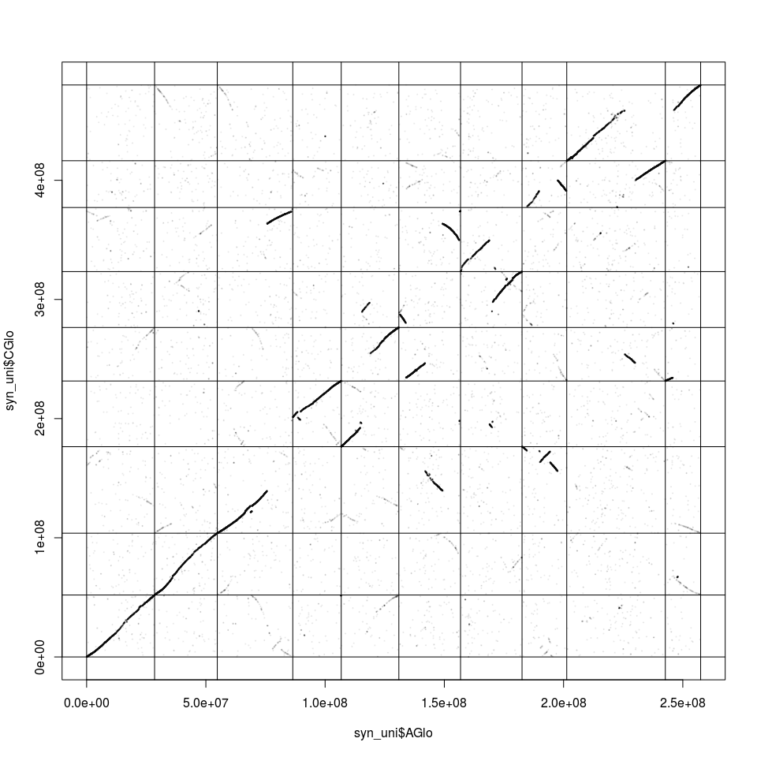

```r
plot(syn_uni$AGlo, syn_uni$CGlo, pch = 19,cex=0.2, col = rgb(0,0,0,alpha = 0.05))
abline(v = c(0, csamax), h=c(0, cscmax))
```

We apply the function `find_blocks` to our dataset.

```r
syn_uni2 <- syn_uni[, c(2, 3, 5, 6)]
names(syn_uni2) <- c("chr1", "pos1", "chr2", "pos2")
synteny_blocks <- find_blocks(syn_uni2, eps = 2000000, minPts = 50,
                              minLength = 1000000, maxLength = 10000000)
```

Lastly, we add an offset to the data.frame.

```r
synteny_blocks$blocks$off1 <- c(0,cumsum(amaxs))[match(synteny_blocks$blocks$chr1, names(amaxs))]
synteny_blocks$blocks$off2 <- c(0,cumsum(cmaxs))[match(synteny_blocks$blocks$chr2, names(cmaxs))]
```

We created a synteny block object that can be used in the *gsrc* package. We can visualize synteny blocks as follows:

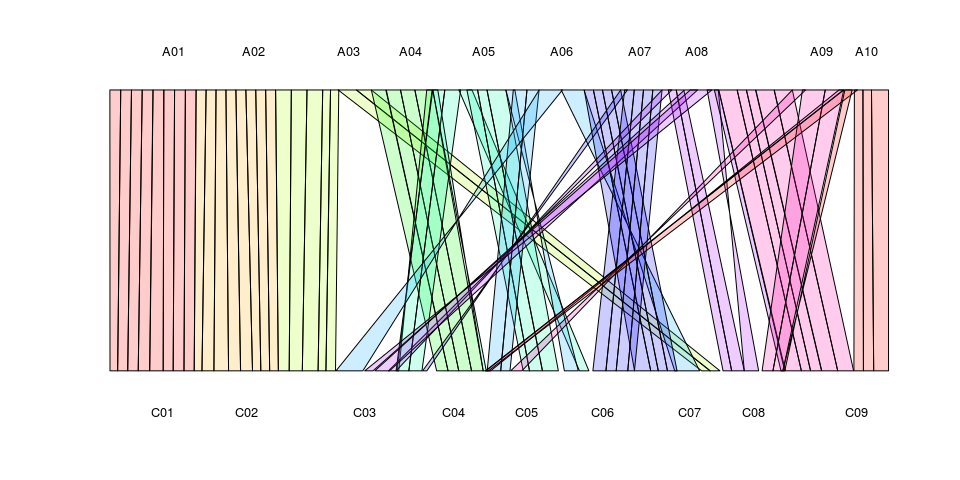

```r
plot.new()
cols <- rainbow(n = 10, start = 0, end = 1, alpha = 0.2)
max1 <- max(synteny_blocks$blocks$end1)
max2 <- max(synteny_blocks$blocks$end2)
axis(3, at = (csamax - min(amaxs) / 2) / max(csamax),
     labels = unique(synA$A.Chr), tick = FALSE, cex.axis = 0.8, las = 1)
axis(1, at = (cscmax - min(cmaxs) / 2) / max(cscmax), labels = unique(synC$C.Chr), tick = FALSE, cex.axis = 0.8, las = 1)
y <- c(1, 1, 0, 0)
for(i in 1:nrow(synteny_blocks$blocks)){
  x <- c(synteny_blocks$blocks$start1[i],
         synteny_blocks$blocks$end1[i],
         synteny_blocks$blocks$end2[i],
         synteny_blocks$blocks$start2[i])
  x <- c(x[1:2] / max1, x[3:4] / max2)
  polygon(x, y, col = cols[unique(synteny_blocks$blocks$chr1) %in% synteny_blocks$blocks$chr1[i]])
}
```

# Synteny blocks form fasta sequences

Here we require only two sequence files in FASTA format and make use of the powerful *DECIPHER* package. The sequences can be from closely related species or subgenomes of allopolyploids. We show the step by step procedure with publicly available data from allotetraploid canola and cotton.

## Canola

First we download the canola data from: [http://www.genoscope.cns.fr/brassicanapus/data/](http://www.genoscope.cns.fr/brassicanapus/data/Brassica_napus_v4.1.chromosomes.fa.gz) and extract it into a local directory. Next we split the file in the A (line 3977960) and C subgenome (line 10756668) in two separate files. Subgenomes A and C consist of 10 and 9 chromosomes, respectively.

```r
library(DECIPHER)
library(dbscan)
library(gsrc)
```

### DECIPHER

To calculate synteny positions, we apply the code provided by the DECIPHER authors [(http://decipher.cee.wisc.edu)](http://decipher.cee.wisc.edu/Screenshots/Example6.html). The computation is time consuming and if you have access to a multi-core system, you should assign multiple cores using the *processors* parameter and increase the memory with the *storage* parameter. *PATHTOSUBGENOMEA* and *PATHTOSUBGENOMEB* are the files we just created by splitting the downloaded FASTA file. *PATHTODB* and *PATHTOSYNTENYFILE* are files that DECIPHER will create to query the sequences and write the output, respectively.

```r
fas <- c(Genome1="PATHTOSUBGENOMEA",
         Genome2="PATHTOSUBGENOMEB")
db <- "PATHTODB"
for (i in seq_along(fas)) {
  Seqs2DB(fas[i], "FASTA", db, names(fas[i]))
}
synteny <- FindSynteny(db, processors = NULL, storage = 5)
save(synteny, file = "PATHTOSYNTENYFILE")
```

### Synteny blocks

Next, we calculate synteny blocks from the mapped sequences. We extract the required data from the synteny object, filter, transform and calculate global positions. The function *FindSynteny* returns a list of alignment result objects, but we only need the second object.

```r
load("brassica_synteny_filtered.rda")
```

```r
syn_uni <- as.data.frame(synteny[[2]])
syn_uni <- syn_uni[syn_uni$score>1500,]
syn_uni <- syn_uni[, c(1,5,7,2,6,8)]
syn_uni <- cbind(syn_uni, rowMeans(syn_uni[, 2:3]), rowMeans(syn_uni[, 5:6]))
syn_uni <- syn_uni[, c(1,7,4,8)]
colnames(syn_uni) <- c("index1", "start1", "index2", "start2")
syn_uni <- syn_uni[order(syn_uni$index1, syn_uni$start1),]
syn_uni$Alev <- as.factor(syn_uni$index1)
syn_uni$Clev <- as.factor(syn_uni$index2)
syn_uni$AGlo <- syn_uni$start1
syn_uni$CGlo <- syn_uni$start2
```

```r
amaxs <- sapply(levels(syn_uni$Alev), function(x) max(syn_uni$start1[syn_uni$index1==x]))
for(i in 2:length(levels(syn_uni$Alev))){
  syn_uni$AGlo[syn_uni$index1 == levels(syn_uni$Alev)[i]] <- syn_uni$AGlo[syn_uni$index1 == levels(syn_uni$Alev)[i]] + sum(amaxs[1:(i-1)])
}

cmaxs <- sapply(levels(syn_uni$Clev), function(x) max(syn_uni$start2[syn_uni$index2==x]))
for(i in 2:length(levels(syn_uni$Clev))){
  syn_uni$CGlo[syn_uni$index2 == levels(syn_uni$Clev)[i]] <- syn_uni$CGlo[syn_uni$index2 == levels(syn_uni$Clev)[i]] + sum(cmaxs[1:(i-1)])
}
csamax <- cumsum(amaxs)
cscmax <- cumsum(cmaxs)
```

We visualize the data and see a general synteny structure in the data.

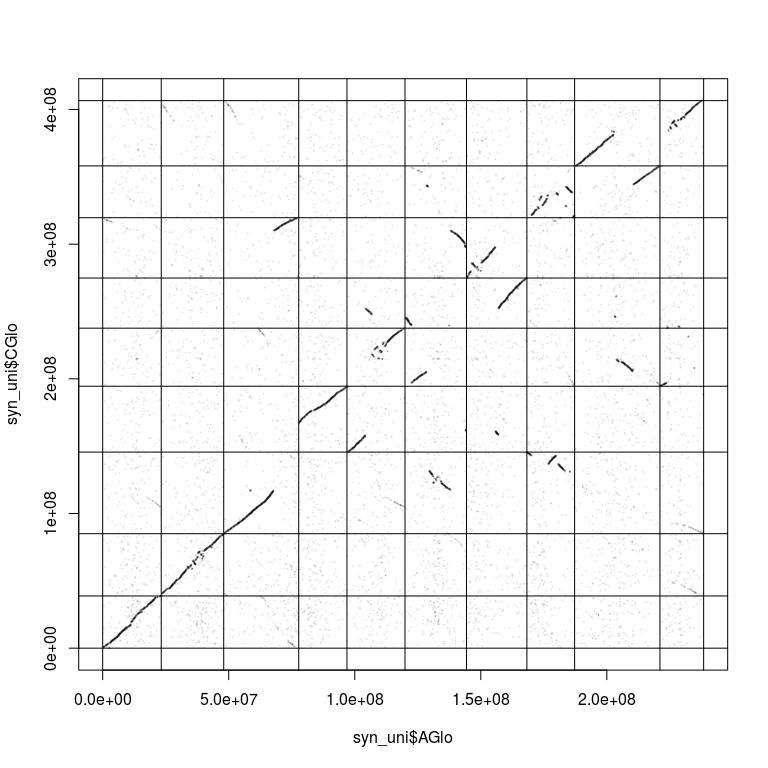

```r
plot(syn_uni$AGlo, syn_uni$CGlo, pch = 19, cex = 0.2, col = rgb(0, 0, 0, alpha = 0.05))
abline(v = c(0, csamax), h=c(0, cscmax))
```

We extract the columns with corresponding alignments and name them.

```r
syn_uni2 <- syn_uni[, c(1, 2, 3, 4)]
names(syn_uni2) <- c("chr1", "pos1", "chr2", "pos2")
```

Once, we have a suitable data.frame with four columns, we call the function *find_blocks* to group the separate alignments into larger synteny blocks.

```r
blocks <- gsrc::find_blocks(syn_uni2, eps = 1500000, minPts = 20, minLength = 1000000, maxLength = 10000000)
```

Finally, we visualize the result. The chromsome numbers do not necessarily represent the official chromosome names, but the order of the sequences in the FASTA file. The start and end positions of synteny blocks are used by *gsrc* to assign SNPs to them.

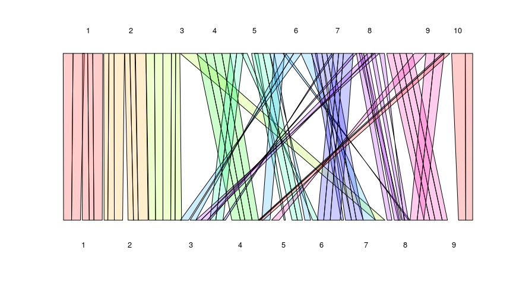

```r
plot.new()
cols <- rainbow(
  n = 10, start = 0, end = 1, alpha = 0.2
)
max1 <- max(blocks$blocks$end1)
max2 <- max(blocks$blocks$end2)
axis(
  3, at = (csamax - min(amaxs) / 2) / max(csamax),
  labels = sort(unique(blocks$blocks$chr1)), tick = FALSE, cex.axis = 0.8, las = 1
)
axis(
  1, at = (cscmax - min(cmaxs) / 2) / max(cscmax),
  labels = sort(unique(blocks$blocks$chr2)), tick = FALSE, cex.axis = 0.8, las = 1
)
y <- c(1, 1, 0, 0)
for (i in 1:nrow(blocks$blocks)) {
  x <- c(
    blocks$blocks$start1[i],
    blocks$blocks$end1[i],
    blocks$blocks$end2[i],
    blocks$blocks$start2[i]
  )
  x <- c(x[1:2] / max1, x[3:4] / max2)
  polygon(x, y, col = cols[unique(blocks$blocks$chr1) %in% blocks$blocks$chr1[i]])
}
```

The synteny block structure is highly similar to the one we obtained with the mapped gene sequences.

## Cotton

We repeat the previously shown steps with data from a cotton project to show the that our approach is not limited to one species. First we download the data from https://www.cottongen.org/data/download/genome. Next we split the file after line 26 because both subgenomes are merged into one file. Each subgenome consists of 13 chromosomes and each chromosome has a header line in the FASTA file.

```r
library(DECIPHER)
library(dbscan)
library(gsrc)
```

### DECIPHER

We use the same procedure as described for canola:

```r
fas <- c(Genome1="PATHTOGENOME1",
         Genome2="PATHTOGENOME2")
db <- "PATHTODB"
for (i in seq_along(fas)) {
  Seqs2DB(fas[i], "FASTA", db, names(fas[i]))
}
synteny <- FindSynteny(db, processors = NULL, storage = 5)
save(synteny, file = "PATHTOSYNTENYFILE")
```

### Synteny blocks

Again, we calculate synteny blocks from the mapped sequences.

```r
load("cotton_synteny_filtered.rda")
```

```r
syn_uniC <- as.data.frame(synteny[[2]])
syn_uniC <- syn_uniC[syn_uniC$score>1500,]
syn_uniC <- syn_uniC[, c(1,5,7,2,6,8)]
syn_uniC <- cbind(syn_uniC, rowMeans(syn_uniC[, 2:3]), rowMeans(syn_uniC[, 5:6]))
syn_uniC <- syn_uniC[, c(1,7,4,8)]
colnames(syn_uniC) <- c("index1", "start1", "index2", "start2")
syn_uniC <- syn_uniC[order(syn_uniC$index1, syn_uniC$start1),]
syn_uniC$Alev <- as.factor(syn_uniC$index1)
syn_uniC$Clev <- as.factor(syn_uniC$index2)
syn_uniC$AGlo <- syn_uniC$start1
syn_uniC$CGlo <- syn_uniC$start2
```

```r
amaxs <- sapply(levels(syn_uniC$Alev), function(x) max(syn_uniC$start1[syn_uniC$index1==x]))
for(i in 2:length(levels(syn_uniC$Alev))){
  syn_uniC$AGlo[syn_uniC$index1 == levels(syn_uniC$Alev)[i]] <- syn_uniC$AGlo[syn_uniC$index1 == levels(syn_uniC$Alev)[i]] + sum(amaxs[1:(i-1)])
}

cmaxs <- sapply(levels(syn_uniC$Clev), function(x) max(syn_uniC$start2[syn_uniC$index2==x]))
for(i in 2:length(levels(syn_uniC$Clev))){
  syn_uniC$CGlo[syn_uniC$index2 == levels(syn_uniC$Clev)[i]] <- syn_uniC$CGlo[syn_uniC$index2 == levels(syn_uniC$Clev)[i]] + sum(cmaxs[1:(i-1)])
}
csamax <- cumsum(amaxs)
cscmax <- cumsum(cmaxs)
```

Again we visualize the data and see a general synteny structure in the data.

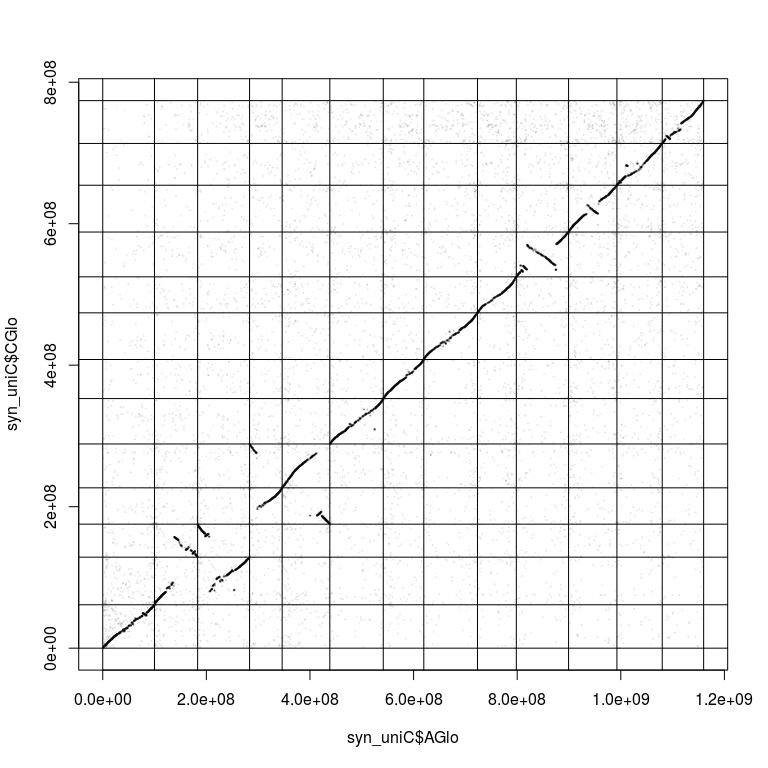

```r
plot(syn_uniC$AGlo, syn_uniC$CGlo, pch = 19, cex = 0.2, col = rgb(0, 0, 0, alpha = 0.05))
abline(v = c(0, csamax), h=c(0, cscmax))
```

```r
syn_uni2 <- syn_uniC[, c(1, 2, 3, 4)]
names(syn_uni2) <- c("chr1", "pos1", "chr2", "pos2")
```

```r
blocks <- gsrc::find_blocks(syn_uni2,eps = 5000000, minPts = 20, minLength = 10000000, maxLength = 50000000)
```

Again, we visualize the result.

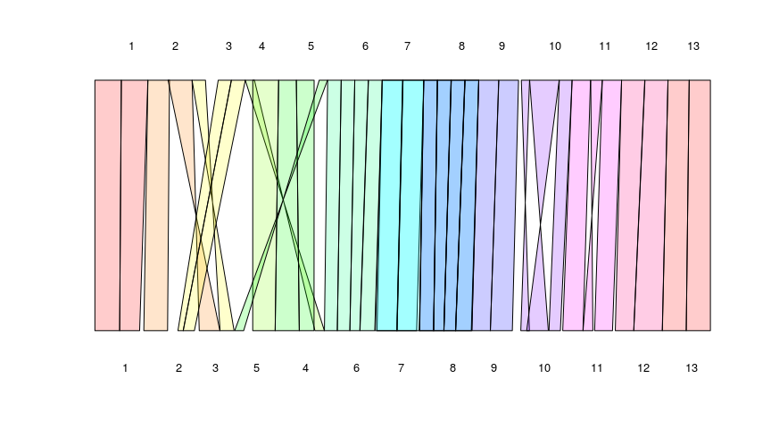

```r
plot.new()
cols <- rainbow(
  n = 13, start = 0, end = 1, alpha = 0.2
)
max1 <- max(blocks$blocks$end1)
max2 <- max(blocks$blocks$end2)
axis(
  3, at = (csamax - min(amaxs) / 2) / max(csamax),
  labels = unique(blocks$blocks$chr1), tick = FALSE, cex.axis = 0.8, las = 1
)
axis(
  1, at = (cscmax - min(cmaxs) / 2) / max(cscmax),
  labels = unique(blocks$blocks$chr2), tick = FALSE, cex.axis = 0.8, las = 1
)
y <- c(1, 1, 0, 0)
for (i in 1:nrow(blocks$blocks)) {
  x <- c(
    blocks$blocks$start1[i],
    blocks$blocks$end1[i],
    blocks$blocks$end2[i],
    blocks$blocks$start2[i]
  )
  x <- c(x[1:2] / max1, x[3:4] / max2)
  polygon(x, y, col = cols[unique(blocks$blocks$chr1) %in% blocks$blocks$chr1[i]])
}
```